# Notebooks

Notes taken from this tutorial: https://www.youtube.com/watch?v=HW29067qVWk

Running "jupyter notebook" starts a server on our local host 8888.

Kernels are basically what programming language you want to use.

*In Jupyter, a "kernel" is a computational engine that executes the code contained in a Jupyter notebook. It is responsible for running the code in the notebook's code cells and interpreting the programming language used in the notebook.*

Noteboks have two different modes: command mode and edit mode.

Command mode allows us to perform actions like adding and deleting cells. You can access command mode by pressing the **Esc** key.

The edit mode allows us to alter the cells. You can access edit mode by pressing the **Enter** key.

```python
print("Hello world!")
```

```
Hello world!
```

Shortcuts:

- **Ctrl + Enter** = Run cell
- **Shift + Enter** = Run cell and select below in command mode
- **Alt + Enter** = Run cell and add new one below in edit mode
- **m** to select markdown mode
- **y** to select code mode

If we include an exclamation mark before the code, the interpreter will run it as a bash command.

```python
!pip list
```

[output not shown]

[output cut: 53 more lines]

[output not shown]

*In Jupyter notebooks, "magics" are special commands that allow you to perform various actions that are not part of standard Python syntax. Magics are prefixed with one or two percent signs (% or %%) and are used to control the behavior of the notebook or to interact with the underlying system.*

*There are two types of magics in Jupyter:*

1. *Line Magics: These magics are prefixed with a single percent sign (%) and apply to a single line of code.*
2. *Cell Magics: These magics are prefixed with two percent signs (%%) and apply to the entire code cell.*

```python
%lsmagic
```

```
Available line magics:
%alias  %alias_magic  %autoawait  %autocall  %automagic  %autosave  %bookmark  %cat  %cd  %clear  %code_wrap  %colors  %conda  %config  %connect_info  %cp  %debug  %dhist  %dirs  %doctest_mode  %ed  %edit  %env  %gui  %hist  %history  %killbgscripts  %ldir  %less  %lf  %lk  %ll  %load  %load_ext  %l…

Available cell magics:
%%!  %%HTML  %%SVG  %%bash  %%capture  %%code_wrap  %%debug  %%file  %%html  %%javascript  %%js  %%latex  %%markdown  %%perl  %%prun  %%pypy  %%python  %%python2  %%python3  %%ruby  %%script  %%sh  %%svg  %%sx  %%system  %%time  %%timeit  %%writefile

Automagic is ON, % prefix IS NOT needed for line magics.
```

```python
# Line magic: Time the execution of a single line of code
%timeit sum(range(1000))
```

```
6.93 µs ± 564 ns per loop (mean ± std. dev. of 7 runs, 100,000 loops each)
```

```python
%%timeit
# Cell magic: Time the execution of multiple lines of code in a cell
# It's important to put the %% command at the beginnng of the cell
total = 0
for i in range(1000):
    total += i
```

```
22.1 µs ± 233 ns per loop (mean ± std. dev. of 7 runs, 10,000 loops each)
```

```python
%%bash
ls
echo -------
pip list
```

[output not shown]

[output cut: 55 more lines]

[output not shown]

```python
pwd
```

```
'/home/auro/Escritorio/Tutorials/jupyter'
```

```python
%pwd
```

```
'/home/auro/Escritorio/Tutorials/jupyter'
```

```python
!pwd
```

```
/home/auro/Escritorio/Tutorials/jupyter
```

```python
%ls -la
```

```
total 100
drwxrwxr-x 3 auro auro  4096 may 22 17:21 ./
drwxrwxr-x 7 auro auro  4096 may 20 15:58 ../
-rw-rw-r-- 1 auro auro 87072 may 15 12:27 00_testing_jupyter.ipynb
drwxrwxr-x 2 auro auro  4096 may 22 17:21 .ipynb_checkpoints/
```

```python
%matplotlib inline
```

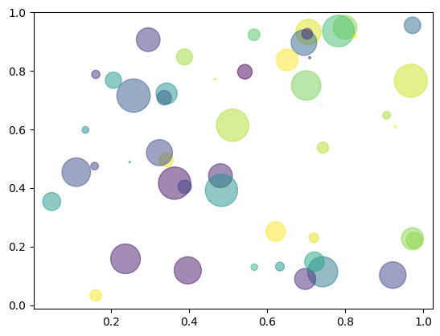

```python
import matplotlib.pyplot as plt
import numpy as np

# Fixing random state for reproducibility
np.random.seed(19680801)


N = 50
x = np.random.rand(N)
y = np.random.rand(N)
colors = np.random.rand(N)
area = (30 * np.random.rand(N))**2  # 0 to 15 point radii

plt.scatter(x, y, s=area, c=colors, alpha=0.5)
plt.show()
```

```python
%%HTML

<iframe width="800" height="400" src="https://www.youtube.com/embed/HW29067qVWk" title="Jupyter Notebook Tutorial: Introduction, Setup, and Walkthrough" frameborder="0" allow="accelerometer; autoplay; clipboard-write; encrypted-media; gyroscope; picture-in-picture; web-share" referrerpolicy="strict-origin-when-cross-origin" allowfullscreen></iframe>
```

[video not shown]

```python
import pandas as pd
import numpy as np

df = pd.DataFrame(np.random.randn(10,5))
df
```

|  | 0 | 1 | 2 | 3 | 4 |
| --- | --- | --- | --- | --- | --- |
| 0 | 0.835275 | 0.181993 | 1.232291 | -0.996842 | -0.804238 |
| 1 | 1.833230 | 0.084046 | -0.466226 | -0.458791 | -0.623695 |
| 2 | 0.645133 | -1.851581 | 0.843342 | 1.093867 | 0.456576 |
| 3 | 0.273131 | -1.916821 | 0.162999 | 0.920437 | -0.667275 |
| 4 | -0.046662 | -0.613771 | -0.374934 | 0.516941 | 0.538914 |
| 5 | 0.001525 | -0.107786 | 0.690347 | 1.480780 | 0.905456 |
| 6 | 1.630140 | 0.053020 | -1.677867 | -0.306046 | -0.161531 |
| 7 | 1.127484 | -0.027809 | 0.029011 | -0.838883 | -0.997609 |
| 8 | 0.196853 | -1.567023 | 0.076813 | 0.229494 | 1.164473 |
| 9 | 0.013561 | -1.131700 | -0.698520 | -1.283327 | -1.034352 |

```python
#Checking checkpoint
```